# tmaps手工调整采样点地图的图例

Jinlong Zhang

11/28/2020

tmap是用来绘制地图的R程序包，作者是荷兰统计学家Martijn Tennekes (https://github.com/mtennekes/tmap)。tmap结合sf、sp等程序包，绘制设色地图、点分布图、栅格图等十分方便，本公众号以前也有介绍。

不过，tmap在绘制复杂的采样点分布图时，默认的图例往往不太理想。tmap用点的形状、颜色分别表示采样点的类型（如森林、湿地、草原），用大小表示数量（物种丰富度等），此时，形状、颜色和大小三个维度是分开的，图例也默认相应分开，而这并不是用户想要的，因此需要对代码进行修改。

本文给出一些示例代码，主要参考Xu S. et al. (2020)论文和附件。相应数据和代码可在 https://github.com/helixcn/ecoinformatics 下载。

## 读取数据

图中需要有指北针和比例尺，要求用蓝色实心三角，表示森林（forest）；绿色实心圆点，表示草地（grassland）；藕荷色实心菱形，表示湿地（wetland）。

```r
setwd("/Users/jinlong/Documents/github/ecoinformatics/2020-11-29_tmap/")
library(tmap)
library(tmaptools)
library(sf)
library(sp)
library(openxlsx)

rm(list = ls()) # 删除工作空间中原来的对象

sites <- read.xlsx("rspb20202063_si_002.xlsx")
head(sites)
```

```
##              Variable           References Country Latitude          Longitude
## 1 Aboveground biomass     Liu et al. 2017b Germany 51.33857 12.378462000000001
## 2 Aboveground biomass     Liu et al. 2017b Germany 51.33857 12.378462000000001
## 3 Belowground biomass Brassard et al. 2011  Canada 49.50000              -89.6
## 4 Belowground biomass Brassard et al. 2011  Canada 49.17000             -89.83
## 5 Belowground biomass    Finér et al. 2017   Spain 40.70000               −1.9
## 6 Belowground biomass    Finér et al. 2017   Spain 40.70000               −1.9
##   MAT.(℃) MAP.(mm) Ecosystem Duration Plant.diversity.level Plot.area.(m2)
## 1   9.545      544    forest     0.29                     2         0.0881
## 2   9.545      544    forest     0.29                     4         0.0881
## 3   2.500      712    forest     1.00                    NA       400.0000
## 4   0.600      823    forest     1.00                    NA       400.0000
## 5  10.200      499    forest       NA                     2       900.0000
## 6  10.200      499    forest       NA                     3       900.0000
##          LnRR
## 1  0.06509796
## 2  0.31643103
## 3  0.53959844
## 4  0.32157929
## 5 -0.36161104
## 6 -0.62003058
```

```r
sites$Longitude <- as.numeric(sites$Longitude) # 某些Longitude或者Latitude记录可能为空，不能识别为numeric类型，因此先要用as.numeric转换。
sites$Latitude <- as.numeric(sites$Latitude)

sites <- sites[!(is.na(sites$Longitude)|is.na(sites$Latitude)),] # 去掉Longitude和latitude为NA的记录

# 建立spatial data.frame
coordinates(sites) <- ~Longitude+Latitude
proj4string(sites) <- CRS("+proj=longlat +datum=WGS84") # 设定WGS84投影

head(sites)
```

```
## class       : SpatialPointsDataFrame
## features    : 6
## extent      : -89.83, 26, 47.3, 51.33857  (xmin, xmax, ymin, ymax)
## crs         : +proj=longlat +datum=WGS84 +no_defs
## variables   : 10
## names       :            Variable,           References, Country,          MAT.(℃), MAP.(mm), Ecosystem, Duration, Plant.diversity.level, Plot.area.(m2),               LnRR
## min values  : Aboveground biomass, Brassard et al. 2011,  Canada,              0.6,      544,    forest,     0.29,                     2,         0.0881, -0.217864917184295
## max values  : Belowground biomass,     Liu et al. 2017b, Romania, 9.54499998254081,      823,    forest,        1,                     4,            900,  0.539598438991999
```

```r
world <- read_sf("world20200121_polygon.shp") #读取shape文件（注意：本图为多边形，没有九段线）
st_crs(world) <- 4326 # 确定WGS84投影
```

## 绘制采样点分布图

默认情况下，地图的图例有三种，分别按照颜色、形状和大小给出。

```
## Scale bar set for latitude km and will be different at the top and bottom of the map.
```

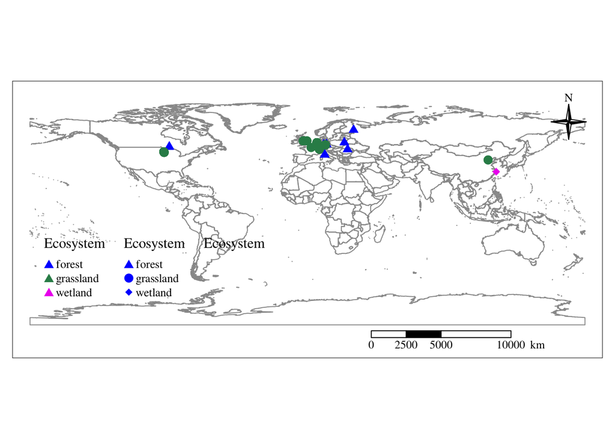

```r
## 01
map01 <- tm_shape(world) +
    tm_borders("grey60", lwd = 1) + # 国界线为灰色
    tm_shape(sites) +
    tm_symbols(shape= "Ecosystem",
        alpha = 1,
        col = "Ecosystem", # 点的颜色按照Ecosystem显示
        border.lwd = 2,
        palette = c("blue", "seagreen4", "magenta2"), # 指定三种颜色
        shapes = c(17, 19, 18), # 点的形状按照Ecosystem显示，分别为17、19、18
        size = 0.3,
        labels = c("forest", "grassland", "wetland"), # 点的名称设定为forest、grassland、wetland
        title.col = "Ecosystem", # 图例名称为Ecosystem
        legend.col.show = TRUE,  # 在图例中显示颜色
        legend.shape.show = TRUE) + # 在图例中显示形状
    tm_scale_bar(breaks = c(0, 2500, 5000, 10000), # 比例尺
        position=c(0.60, 0.0), # 比例尺在地图中的位置
        text.size = 1) +
    tm_compass(type = "4star", # 指北针类型
        position=c("right", "top"), # 指北针位置
        size = 2.5) + # 指北针大小
    tm_layout(inner.margins=c(0.12,0.03,0.08,0.03), # 地图边缘的大小
        legend.stack = "horizontal", # 图例排列
        fontfamily = "FreeSerif") +  # Times New Roman （MacOS）
    tm_legend(position=c(0.05, 0.20), # 图例放在图左下角
        legend.text.size = 0.8,
        legend.title.size = 1.2) +
    tm_add_legend(
        type = "symbol",
        title = "Ecosystem" # 图例标题
    )

map01
```

```r
## 8inches by 5 inches, 600dpi
# jpeg("map01.jpeg", width = 8*600, height = 5*600, res = 600)
# map01
# dev.off()
```

## 更改图例后的地图

用tm_add_legend手工调整：

```r
tm_add_legend(
    type = "symbol",
    labels = c("grassland", "forest", "wetland"),
    col = c("seagreen4", "blue", "magenta2"),
    shape = c(19, 17, 18),
    title = "Ecosystem"
)
```

更改后的代码：

```
## Scale bar set for latitude km and will be different at the top and bottom of the map.
```

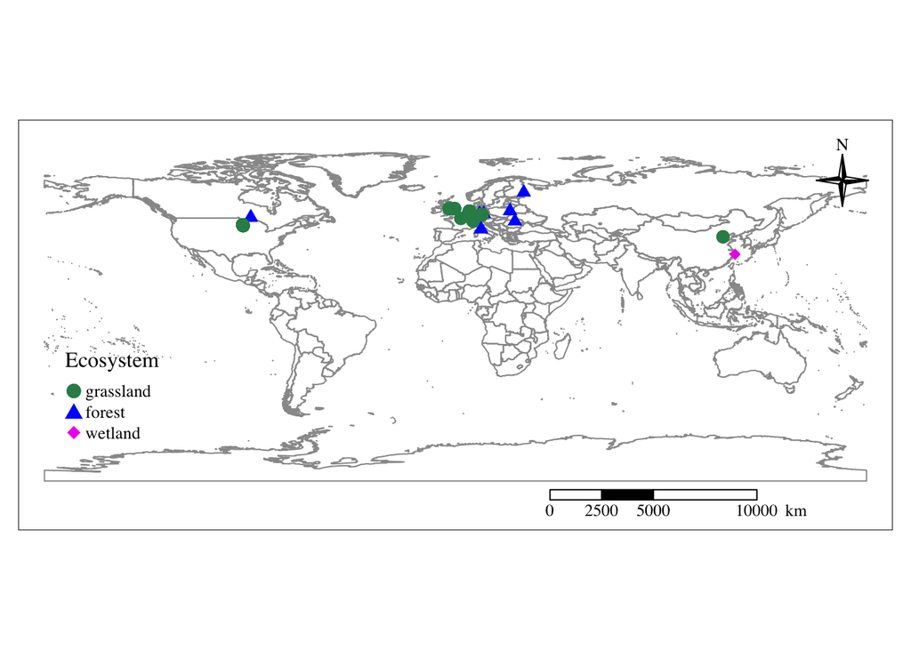

```r
# 02
map02 <- tm_shape(world) +
    tm_borders("grey60", lwd = 1) +
    tm_shape(sites) +
    tm_symbols(shape= "Ecosystem",
        alpha = 1,
        col = "Ecosystem",
        border.lwd = 2,
        palette = c("blue", "seagreen4", "magenta2"),
        shapes = c(17, 19, 18),
        size = 0.3,
        labels = c("forest", "grassland", "wetland"),
        title.col = "Ecosystem",
        legend.col.show = FALSE,
        legend.shape.show = FALSE) +
    tm_scale_bar(breaks = c(0, 2500, 5000, 10000),
        position=c(0.60, 0.0),
        text.size = 1) +
    tm_compass(type = "4star",
        position=c("right", "top"),
        size = 2.5) +
    tm_layout(inner.margins=c(0.12,0.03,0.08,0.03),
        legend.stack = "horizontal",
        fontfamily = "serif") +
    tm_legend(position=c(0.05, 0.20),
        legend.text.size = 0.8,
        legend.title.size = 1.2) +
    tm_add_legend(
        type = "symbol",
        labels = c("grassland", "forest", "wetland"), # 图例的标签
        col = c("seagreen4", "blue", "magenta2"), # 图例颜色
        shape = c(19, 17, 18), # 图例
        title = "Ecosystem"
    )


map02
```

```r
## 8inches by 5 inches, 600dpi
# jpeg("map02.jpeg", width = 8*600, height = 5*600, res = 600)
# map02
# dev.off()
```

## 附：绘制欧洲部分的地图

```
## Scale bar set for latitude km and will be different at the top and bottom of the map.
```

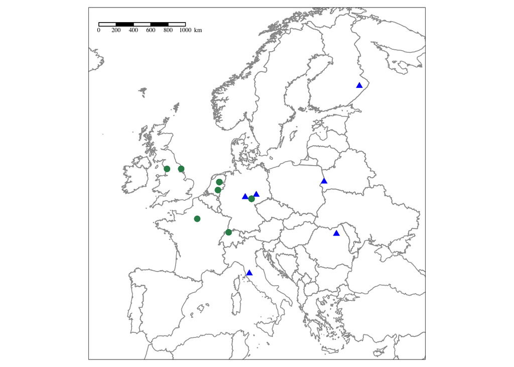

```r
# 03
map03 <- tm_shape(world,
        xlim = c(-15, 40), # 经度范围
        ylim = c(35, 70)) + # 纬度范围
    tm_borders("grey60", lwd = 1) +
    tm_shape(sites) +
    tm_symbols(shape= "Ecosystem",
        col = "Ecosystem",
        palette = c("blue", "seagreen4", "magenta2"),
        size = 0.2,
        shapes = c(17, 19, 18),
        border.lwd = 1.8) +
    tm_scale_bar(position = c("left", "top")) +
    tm_layout(legend.show = FALSE, fontfamily = "serif")

map03
```

```r
## 4 inches by 5 inches, 600dpi
# jpeg("map03.jpeg", width = 4*400, height = 5*400, res = 600)
# map03
# dev.off()
```

## 参考：

- Xu, S., Eisenhauer, N., Ferlian, O., Zhang, J., Zhou, G., Lu, X., Liu, C., & Zhang, D. (2020). Species richness promotes ecosystem carbon storage: Evidence from biodiversity-ecosystem functioning experiments. Proceedings of the Royal Society B, 287(1939), 20202063. (https://doi.org/10.1098/rspb.2020.2063)
- Tennekes M (2018). “tmap: Thematic Maps in R.” Journal of Statistical Software, 84(6), 1-39. doi: 10.18637/jss.v084.i06 (https://doi.org/10.18637/jss.v084.i06).